# Optimal Treatment Analysis

## Outcome Variable

**Outcome Variable:** haz

## Predictor Variables

**Intervention Variable:** impfloor

**Adjustment Set:**

- arm
- sex
- W_mage
- meducyrs
- feducyrs
- hhwealth_quart
- hfoodsec
- W_mhtcm
- W_mwtkg
- W_mbmi
- W_nrooms
- W_nchldlt5
- W_parity
- impsan
- safeh20
- delta_W_mage
- delta_meducyrs
- delta_feducyrs
- delta_hhwealth_quart
- delta_hfoodsec
- delta_W_mhtcm
- delta_W_mwtkg
- delta_W_mbmi
- delta_W_nrooms
- delta_W_nchldlt5
- delta_W_parity
- delta_impsan
- delta_safeh20

## Stratifying Variables

The analysis was stratified on these variable(s):

- agecat
- studyid
- country

## Data Summary

| agecat | studyid | country | impfloor | n_cell | n |
| --- | --- | --- | --- | --- | --- |
| Birth | CMC-V-BCS-2002 | INDIA | 1 | 72 | 72 |
| Birth | CMC-V-BCS-2002 | INDIA | 0 | 0 | 72 |
| Birth | CONTENT | PERU | 1 | 2 | 2 |
| Birth | CONTENT | PERU | 0 | 0 | 2 |
| Birth | GMS-Nepal | NEPAL | 1 | 100 | 544 |
| Birth | GMS-Nepal | NEPAL | 0 | 444 | 544 |
| Birth | IRC | INDIA | 1 | 287 | 287 |
| Birth | IRC | INDIA | 0 | 0 | 287 |
| Birth | JiVitA-3 | BANGLADESH | 1 | 1394 | 22399 |
| Birth | JiVitA-3 | BANGLADESH | 0 | 21005 | 22399 |
| Birth | JiVitA-4 | BANGLADESH | 1 | 307 | 2820 |
| Birth | JiVitA-4 | BANGLADESH | 0 | 2513 | 2820 |
| Birth | MAL-ED | BANGLADESH | 1 | 196 | 213 |
| Birth | MAL-ED | BANGLADESH | 0 | 17 | 213 |
| Birth | MAL-ED | BRAZIL | 1 | 58 | 60 |
| Birth | MAL-ED | BRAZIL | 0 | 2 | 60 |
| Birth | MAL-ED | INDIA | 1 | 35 | 41 |
| Birth | MAL-ED | INDIA | 0 | 6 | 41 |
| Birth | MAL-ED | NEPAL | 1 | 9 | 25 |
| Birth | MAL-ED | NEPAL | 0 | 16 | 25 |
| Birth | MAL-ED | PERU | 1 | 39 | 215 |
| Birth | MAL-ED | PERU | 0 | 176 | 215 |
| Birth | MAL-ED | SOUTH AFRICA | 1 | 87 | 96 |
| Birth | MAL-ED | SOUTH AFRICA | 0 | 9 | 96 |
| Birth | MAL-ED | TANZANIA, UNITED REPUBLIC OF | 1 | 7 | 119 |
| Birth | MAL-ED | TANZANIA, UNITED REPUBLIC OF | 0 | 112 | 119 |
| Birth | NIH-Birth | BANGLADESH | 1 | 533 | 605 |
| Birth | NIH-Birth | BANGLADESH | 0 | 72 | 605 |
| Birth | NIH-Crypto | BANGLADESH | 1 | 558 | 732 |
| Birth | NIH-Crypto | BANGLADESH | 0 | 174 | 732 |

[output cut: 66 more lines]

The following strata were considered:

- agecat: 24 months, studyid: CMC-V-BCS-2002, country: INDIA
- agecat: 24 months, studyid: CONTENT, country: PERU
- agecat: 24 months, studyid: GMS-Nepal, country: NEPAL
- agecat: 24 months, studyid: IRC, country: INDIA
- agecat: 24 months, studyid: JiVitA-3, country: BANGLADESH
- agecat: 24 months, studyid: JiVitA-4, country: BANGLADESH
- agecat: 24 months, studyid: MAL-ED, country: BANGLADESH
- agecat: 24 months, studyid: MAL-ED, country: BRAZIL
- agecat: 24 months, studyid: MAL-ED, country: INDIA
- agecat: 24 months, studyid: MAL-ED, country: NEPAL
- agecat: 24 months, studyid: MAL-ED, country: PERU
- agecat: 24 months, studyid: MAL-ED, country: SOUTH AFRICA
- agecat: 24 months, studyid: MAL-ED, country: TANZANIA, UNITED REPUBLIC OF
- agecat: 24 months, studyid: NIH-Birth, country: BANGLADESH
- agecat: 24 months, studyid: NIH-Crypto, country: BANGLADESH
- agecat: 24 months, studyid: PROVIDE, country: BANGLADESH
- agecat: 6 months, studyid: CMC-V-BCS-2002, country: INDIA
- agecat: 6 months, studyid: CONTENT, country: PERU
- agecat: 6 months, studyid: GMS-Nepal, country: NEPAL
- agecat: 6 months, studyid: IRC, country: INDIA
- agecat: 6 months, studyid: JiVitA-3, country: BANGLADESH
- agecat: 6 months, studyid: JiVitA-4, country: BANGLADESH
- agecat: 6 months, studyid: MAL-ED, country: BANGLADESH
- agecat: 6 months, studyid: MAL-ED, country: BRAZIL
- agecat: 6 months, studyid: MAL-ED, country: INDIA
- agecat: 6 months, studyid: MAL-ED, country: NEPAL
- agecat: 6 months, studyid: MAL-ED, country: PERU
- agecat: 6 months, studyid: MAL-ED, country: SOUTH AFRICA
- agecat: 6 months, studyid: MAL-ED, country: TANZANIA, UNITED REPUBLIC OF
- agecat: 6 months, studyid: NIH-Birth, country: BANGLADESH
- agecat: 6 months, studyid: NIH-Crypto, country: BANGLADESH
- agecat: 6 months, studyid: PROVIDE, country: BANGLADESH
- agecat: Birth, studyid: CMC-V-BCS-2002, country: INDIA
- agecat: Birth, studyid: CONTENT, country: PERU
- agecat: Birth, studyid: GMS-Nepal, country: NEPAL
- agecat: Birth, studyid: IRC, country: INDIA
- agecat: Birth, studyid: JiVitA-3, country: BANGLADESH
- agecat: Birth, studyid: JiVitA-4, country: BANGLADESH
- agecat: Birth, studyid: MAL-ED, country: BANGLADESH
- agecat: Birth, studyid: MAL-ED, country: BRAZIL
- agecat: Birth, studyid: MAL-ED, country: INDIA
- agecat: Birth, studyid: MAL-ED, country: NEPAL
- agecat: Birth, studyid: MAL-ED, country: PERU
- agecat: Birth, studyid: MAL-ED, country: SOUTH AFRICA
- agecat: Birth, studyid: MAL-ED, country: TANZANIA, UNITED REPUBLIC OF
- agecat: Birth, studyid: NIH-Birth, country: BANGLADESH
- agecat: Birth, studyid: NIH-Crypto, country: BANGLADESH
- agecat: Birth, studyid: PROVIDE, country: BANGLADESH

### Dropped Strata

- agecat: Birth, studyid: CMC-V-BCS-2002, country: INDIA
- agecat: Birth, studyid: CONTENT, country: PERU
- agecat: Birth, studyid: IRC, country: INDIA
- agecat: Birth, studyid: MAL-ED, country: BRAZIL
- agecat: 6 months, studyid: CMC-V-BCS-2002, country: INDIA
- agecat: 6 months, studyid: IRC, country: INDIA
- agecat: 6 months, studyid: MAL-ED, country: BRAZIL
- agecat: 24 months, studyid: CMC-V-BCS-2002, country: INDIA
- agecat: 24 months, studyid: IRC, country: INDIA
- agecat: 24 months, studyid: MAL-ED, country: BRAZIL

## Methods Detail

We’re interested in the causal parameters $E[Y_a]$ for all values of $a \in \mathcal{A}$. These parameters represent the mean outcome if, possibly contrary to fact, we intervened to set all units to have $A=a$. Under the randomization and positivity assumptions, these are identified by the statistical parameters $\psi_a=E_W[E_{Y|A,W}(Y|A=a,W)]$. In addition, we’re interested in the mean of $Y$, $E[Y]$ under no intervention (the observed mean). We will estimate these parameters by using SuperLearner to fit the relevant likelihood factors – $E_{Y|A,W}(Y|A=a,W)$ and $p(A=a|W)$, and then updating our likelihood fit using a joint TMLE.

For unadjusted analyses ($W=\{\}$), initial likelihoods were estimated using Lrnr_glm to estimate the simple $E(Y|A)$ and Lrnr_mean to estimate $p(A)$. For adjusted analyses, a small library containing Lrnr_glmnet, Lrnr_xgboost, and Lrnr_mean was used.

# Results Detail

## Results Plots

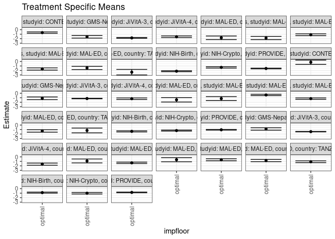

## Results Table

### Parameter: TSM

| agecat | studyid | country | intervention_level | baseline_level | estimate | ci_lower | ci_upper |
| --- | --- | --- | --- | --- | --- | --- | --- |
| Birth | GMS-Nepal | NEPAL | optimal | observed | -0.8662361 | -1.1391514 | -0.5933208 |
| Birth | JiVitA-3 | BANGLADESH | optimal | observed | -1.4617404 | -1.5168036 | -1.4066772 |
| Birth | JiVitA-4 | BANGLADESH | optimal | observed | -1.6128177 | -1.8507538 | -1.3748817 |
| Birth | MAL-ED | BANGLADESH | optimal | observed | -0.9104926 | -1.3435346 | -0.4774505 |
| Birth | MAL-ED | INDIA | optimal | observed | -1.3299769 | -1.4919745 | -1.1679793 |
| Birth | MAL-ED | NEPAL | optimal | observed | -0.6317325 | -1.0889591 | -0.1745060 |
| Birth | MAL-ED | PERU | optimal | observed | -0.6444287 | -0.8657404 | -0.4231170 |
| Birth | MAL-ED | SOUTH AFRICA | optimal | observed | -0.8177252 | -1.0676681 | -0.5677822 |
| Birth | MAL-ED | TANZANIA, UNITED REPUBLIC OF | optimal | observed | -1.0794347 | -1.2806603 | -0.8782091 |
| Birth | NIH-Birth | BANGLADESH | optimal | observed | -0.8768595 | -0.9941562 | -0.7595628 |
| Birth | NIH-Crypto | BANGLADESH | optimal | observed | -1.0126390 | -1.1863975 | -0.8388804 |
| Birth | PROVIDE | BANGLADESH | optimal | observed | -0.8311766 | -0.9106269 | -0.7517263 |
| 6 months | CONTENT | PERU | optimal | observed | -0.1680031 | -0.6491034 | 0.3130972 |
| 6 months | GMS-Nepal | NEPAL | optimal | observed | -1.1135175 | -1.4154768 | -0.8115582 |
| 6 months | JiVitA-3 | BANGLADESH | optimal | observed | -1.1710577 | -1.2302254 | -1.1118901 |
| 6 months | JiVitA-4 | BANGLADESH | optimal | observed | -1.2037043 | -1.3757568 | -1.0316518 |
| 6 months | MAL-ED | BANGLADESH | optimal | observed | -1.4547984 | -1.9428828 | -0.9667141 |
| 6 months | MAL-ED | INDIA | optimal | observed | -1.1756105 | -1.6111521 | -0.7400689 |
| 6 months | MAL-ED | NEPAL | optimal | observed | -0.3776008 | -0.5237031 | -0.2314984 |
| 6 months | MAL-ED | PERU | optimal | observed | -1.1867203 | -1.3502815 | -1.0231591 |
| 6 months | MAL-ED | SOUTH AFRICA | optimal | observed | -1.3061145 | -1.5818437 | -1.0303853 |
| 6 months | MAL-ED | TANZANIA, UNITED REPUBLIC OF | optimal | observed | -1.2008271 | -1.7288184 | -0.6728358 |
| 6 months | NIH-Birth | BANGLADESH | optimal | observed | -1.3996971 | -1.5324051 | -1.2669891 |
| 6 months | NIH-Crypto | BANGLADESH | optimal | observed | -1.2251858 | -1.3392669 | -1.1111048 |
| 6 months | PROVIDE | BANGLADESH | optimal | observed | -1.0480127 | -1.1229017 | -0.9731237 |
| 24 months | CONTENT | PERU | optimal | observed | -0.6520802 | -0.8086837 | -0.4954766 |
| 24 months | GMS-Nepal | NEPAL | optimal | observed | -1.5848772 | -1.8701824 | -1.2995719 |
| 24 months | JiVitA-3 | BANGLADESH | optimal | observed | -1.8331206 | -1.9198792 | -1.7463621 |
| 24 months | JiVitA-4 | BANGLADESH | optimal | observed | -1.5740577 | -1.7615852 | -1.3865302 |
| 24 months | MAL-ED | BANGLADESH | optimal | observed | -1.8053847 | -2.2004956 | -1.4102737 |
| 24 months | MAL-ED | INDIA | optimal | observed | -1.8548148 | -2.2085486 | -1.5010810 |
| 24 months | MAL-ED | NEPAL | optimal | observed | -1.1195339 | -1.3213009 | -0.9177669 |
| 24 months | MAL-ED | PERU | optimal | observed | -1.6707689 | -1.9120177 | -1.4295201 |
| 24 months | MAL-ED | SOUTH AFRICA | optimal | observed | -1.4392955 | -1.7996308 | -1.0789602 |
| 24 months | MAL-ED | TANZANIA, UNITED REPUBLIC OF | optimal | observed | -2.3850819 | -2.9993276 | -1.7708361 |
| 24 months | NIH-Birth | BANGLADESH | optimal | observed | -2.1604572 | -2.2687836 | -2.0521309 |
| 24 months | NIH-Crypto | BANGLADESH | optimal | observed | -1.3159630 | -1.4648033 | -1.1671227 |
| 24 months | PROVIDE | BANGLADESH | optimal | observed | -1.5614706 | -1.6467309 | -1.4762102 |

### Parameter: E(Y)

| agecat | studyid | country | intervention_level | baseline_level | estimate | ci_lower | ci_upper |
| --- | --- | --- | --- | --- | --- | --- | --- |
| Birth | GMS-Nepal | NEPAL | observed | observed | -1.1177022 | -1.2075344 | -1.0278700 |
| Birth | JiVitA-3 | BANGLADESH | observed | observed | -1.5895451 | -1.6088186 | -1.5702715 |
| Birth | JiVitA-4 | BANGLADESH | observed | observed | -1.5236135 | -1.5727559 | -1.4744711 |
| Birth | MAL-ED | BANGLADESH | observed | observed | -1.0530516 | -1.1896058 | -0.9164975 |
| Birth | MAL-ED | INDIA | observed | observed | -1.2070732 | -1.5254820 | -0.8886644 |
| Birth | MAL-ED | NEPAL | observed | observed | -0.7828000 | -1.1547571 | -0.4108429 |
| Birth | MAL-ED | PERU | observed | observed | -0.9141395 | -1.0364098 | -0.7918693 |
| Birth | MAL-ED | SOUTH AFRICA | observed | observed | -0.5523958 | -0.7550074 | -0.3497843 |
| Birth | MAL-ED | TANZANIA, UNITED REPUBLIC OF | observed | observed | -1.1213445 | -1.3341800 | -0.9085090 |
| Birth | NIH-Birth | BANGLADESH | observed | observed | -0.9289256 | -1.0178691 | -0.8399821 |
| Birth | NIH-Crypto | BANGLADESH | observed | observed | -0.9094945 | -0.9809370 | -0.8380521 |
| Birth | PROVIDE | BANGLADESH | observed | observed | -0.8851020 | -0.9601332 | -0.8100709 |
| 6 months | CONTENT | PERU | observed | observed | -0.2785256 | -0.4098735 | -0.1471776 |
| 6 months | GMS-Nepal | NEPAL | observed | observed | -1.3225094 | -1.4115793 | -1.2334396 |
| 6 months | JiVitA-3 | BANGLADESH | observed | observed | -1.3134597 | -1.3365976 | -1.2903219 |
| 6 months | JiVitA-4 | BANGLADESH | observed | observed | -1.3440174 | -1.3812821 | -1.3067527 |
| 6 months | MAL-ED | BANGLADESH | observed | observed | -1.2026806 | -1.3203025 | -1.0850586 |
| 6 months | MAL-ED | INDIA | observed | observed | -1.2070638 | -1.3255909 | -1.0885368 |
| 6 months | MAL-ED | NEPAL | observed | observed | -0.5534862 | -0.6681825 | -0.4387899 |
| 6 months | MAL-ED | PERU | observed | observed | -1.3248549 | -1.4336721 | -1.2160378 |
| 6 months | MAL-ED | SOUTH AFRICA | observed | observed | -1.0547925 | -1.1843544 | -0.9252306 |
| 6 months | MAL-ED | TANZANIA, UNITED REPUBLIC OF | observed | observed | -1.3700408 | -1.4930436 | -1.2470380 |
| 6 months | NIH-Birth | BANGLADESH | observed | observed | -1.4060639 | -1.4948910 | -1.3172368 |
| 6 months | NIH-Crypto | BANGLADESH | observed | observed | -1.1986783 | -1.2700937 | -1.1272630 |
| 6 months | PROVIDE | BANGLADESH | observed | observed | -1.0916915 | -1.1661176 | -1.0172654 |
| 24 months | CONTENT | PERU | observed | observed | -0.6868598 | -0.8388476 | -0.5348719 |
| 24 months | GMS-Nepal | NEPAL | observed | observed | -1.8396747 | -1.9349390 | -1.7444104 |
| 24 months | JiVitA-3 | BANGLADESH | observed | observed | -2.0134592 | -2.0410825 | -1.9858359 |
| 24 months | JiVitA-4 | BANGLADESH | observed | observed | -1.7804046 | -1.8159135 | -1.7448956 |
| 24 months | MAL-ED | BANGLADESH | observed | observed | -1.9783962 | -2.1050210 | -1.8517715 |
| 24 months | MAL-ED | INDIA | observed | observed | -1.8861894 | -2.0110006 | -1.7613783 |
| 24 months | MAL-ED | NEPAL | observed | observed | -1.2928054 | -1.4146944 | -1.1709164 |
| 24 months | MAL-ED | PERU | observed | observed | -1.7524710 | -1.8736426 | -1.6312994 |
| 24 months | MAL-ED | SOUTH AFRICA | observed | observed | -1.6450595 | -1.7797240 | -1.5103950 |
| 24 months | MAL-ED | TANZANIA, UNITED REPUBLIC OF | observed | observed | -2.6432311 | -2.7795797 | -2.5068826 |
| 24 months | NIH-Birth | BANGLADESH | observed | observed | -2.2235968 | -2.3265592 | -2.1206344 |
| 24 months | NIH-Crypto | BANGLADESH | observed | observed | -1.4412646 | -1.5249156 | -1.3576135 |
| 24 months | PROVIDE | BANGLADESH | observed | observed | -1.6024221 | -1.6857420 | -1.5191023 |

### Parameter: PAR

| agecat | studyid | country | intervention_level | baseline_level | estimate | ci_lower | ci_upper |
| --- | --- | --- | --- | --- | --- | --- | --- |
| Birth | GMS-Nepal | NEPAL | optimal | observed | -0.2514661 | -0.5175455 | 0.0146133 |
| Birth | JiVitA-3 | BANGLADESH | optimal | observed | -0.1278047 | -0.1800351 | -0.0755743 |
| Birth | JiVitA-4 | BANGLADESH | optimal | observed | 0.0892043 | -0.1377424 | 0.3161510 |
| Birth | MAL-ED | BANGLADESH | optimal | observed | -0.1425591 | -0.5527628 | 0.2676447 |
| Birth | MAL-ED | INDIA | optimal | observed | 0.1229037 | -0.2153857 | 0.4611931 |
| Birth | MAL-ED | NEPAL | optimal | observed | -0.1510675 | -0.4628232 | 0.1606882 |
| Birth | MAL-ED | PERU | optimal | observed | -0.2697109 | -0.4496365 | -0.0897852 |
| Birth | MAL-ED | SOUTH AFRICA | optimal | observed | 0.2653293 | 0.0385778 | 0.4920809 |
| Birth | MAL-ED | TANZANIA, UNITED REPUBLIC OF | optimal | observed | -0.0419099 | -0.1416261 | 0.0578063 |
| Birth | NIH-Birth | BANGLADESH | optimal | observed | -0.0520661 | -0.1278365 | 0.0237043 |
| Birth | NIH-Crypto | BANGLADESH | optimal | observed | 0.1031444 | -0.0477907 | 0.2540796 |
| Birth | PROVIDE | BANGLADESH | optimal | observed | -0.0539254 | -0.0853841 | -0.0224667 |
| 6 months | CONTENT | PERU | optimal | observed | -0.1105225 | -0.5780387 | 0.3569938 |
| 6 months | GMS-Nepal | NEPAL | optimal | observed | -0.2089920 | -0.5029843 | 0.0850003 |
| 6 months | JiVitA-3 | BANGLADESH | optimal | observed | -0.1424020 | -0.2020691 | -0.0827349 |
| 6 months | JiVitA-4 | BANGLADESH | optimal | observed | -0.1403131 | -0.3069537 | 0.0263275 |
| 6 months | MAL-ED | BANGLADESH | optimal | observed | 0.2521179 | -0.2020599 | 0.7062957 |
| 6 months | MAL-ED | INDIA | optimal | observed | -0.0314533 | -0.4476012 | 0.3846945 |
| 6 months | MAL-ED | NEPAL | optimal | observed | -0.1758854 | -0.2932083 | -0.0585625 |
| 6 months | MAL-ED | PERU | optimal | observed | -0.1381346 | -0.2587298 | -0.0175395 |
| 6 months | MAL-ED | SOUTH AFRICA | optimal | observed | 0.2513220 | -0.0091301 | 0.5117741 |
| 6 months | MAL-ED | TANZANIA, UNITED REPUBLIC OF | optimal | observed | -0.1692137 | -0.6824411 | 0.3440136 |
| 6 months | NIH-Birth | BANGLADESH | optimal | observed | -0.0063668 | -0.1025486 | 0.0898150 |
| 6 months | NIH-Crypto | BANGLADESH | optimal | observed | 0.0265075 | -0.0569923 | 0.1100074 |
| 6 months | PROVIDE | BANGLADESH | optimal | observed | -0.0436788 | -0.0721005 | -0.0152571 |
| 24 months | CONTENT | PERU | optimal | observed | -0.0347796 | -0.0767985 | 0.0072393 |
| 24 months | GMS-Nepal | NEPAL | optimal | observed | -0.2547975 | -0.5305673 | 0.0209723 |
| 24 months | JiVitA-3 | BANGLADESH | optimal | observed | -0.1803385 | -0.2677587 | -0.0929183 |
| 24 months | JiVitA-4 | BANGLADESH | optimal | observed | -0.2063469 | -0.3879418 | -0.0247519 |
| 24 months | MAL-ED | BANGLADESH | optimal | observed | -0.1730116 | -0.5568462 | 0.2108231 |
| 24 months | MAL-ED | INDIA | optimal | observed | -0.0313746 | -0.3571192 | 0.2943700 |
| 24 months | MAL-ED | NEPAL | optimal | observed | -0.1732715 | -0.3253693 | -0.0211737 |
| 24 months | MAL-ED | PERU | optimal | observed | -0.0817021 | -0.2768214 | 0.1134172 |
| 24 months | MAL-ED | SOUTH AFRICA | optimal | observed | -0.2057640 | -0.5566011 | 0.1450730 |
| 24 months | MAL-ED | TANZANIA, UNITED REPUBLIC OF | optimal | observed | -0.2581493 | -0.8616254 | 0.3453269 |
| 24 months | NIH-Birth | BANGLADESH | optimal | observed | -0.0631396 | -0.1024115 | -0.0238676 |
| 24 months | NIH-Crypto | BANGLADESH | optimal | observed | -0.1253016 | -0.2493515 | -0.0012517 |
| 24 months | PROVIDE | BANGLADESH | optimal | observed | -0.0409516 | -0.0684997 | -0.0134035 |